# ML Week 1: Ridge, LASSO and Elastic Net Regression

## Task: A local Grinnell realtor, Armenta, put these data together to see what patterns might be found, perhaps with an improvement in how one sells houses or buys them. You have been assigned this task to help the realtor. Make a Linear Model with Linear Regression, Lasso, Ridge and Elastic Net Regression.

**Format**

- A data frame with 929 observations on the following 15 variables.

**Attribute Information**

- Date: Coded value for date of sale (Jan 1, 2005=16436)
- Address: Street address of the house
- Bedrooms: Number of bedrooms
- Baths: Number of bathrooms
- SquareFeet: The square footage of the home's living space
- LotSize: Lot size (in acres)
- YearBuilt: Year the house was built; many pre-1900 homes are listed as 1900
- YearSold: The year the house was sold, for this case
- MonthSold: The month the house was sold (1=Jan, 2=Feb, to 12=Dec)
- DaySold: Day of the month the house was sold (1 to 31)
- CostPerSqFt: SalePrice / SquareFeet (round to nearest penny)
- OrigPrice: List price of the house when originally put on the market (dollars)
- ListPrice: List price at the time of sale (dollars)
- SalePrice: Sale price of the house (dollars)
- SPLPPct: (Sale_Price / List_Price ) * 100

```python
import numpy as np
import pandas as pd
import matplotlib.pyplot as plt
import seaborn as sns
from sklearn.linear_model import LinearRegression
from sklearn.model_selection import train_test_split
from sklearn.preprocessing import StandardScaler
from sklearn import linear_model
from sklearn.metrics import mean_squared_error
```

**Import the data**

```python
df=pd.read_csv('GrinnellHouses.csv').drop('Unnamed: 0',axis=1)
```

**Check the head of the data**

```python
df.head()
```

|  | Date | Address | Bedrooms | Baths | SquareFeet | LotSize | YearBuilt | YearSold | MonthSold | DaySold | CostPerSqFt | OrigPrice | ListPrice | SalePrice | SPLPPct |
| --- | --- | --- | --- | --- | --- | --- | --- | --- | --- | --- | --- | --- | --- | --- | --- |
| 0 | 16695 | 1510 First Ave #112 | 2 | 1.0 | 1120.0 | NaN | 1993 | 2005 | 9 | 16 | 6.25 | 17000 | 10500 | 7000 | 66.67 |
| 1 | 16880 | 1020 Center St | 3 | 1.0 | 1224.0 | 0.172176 | 1900 | 2006 | 3 | 20 | 22.06 | 35000 | 35000 | 27000 | 77.14 |
| 2 | 16875 | 918 Chatterton St | 4 | 1.0 | 1540.0 | NaN | 1970 | 2006 | 3 | 15 | 18.18 | 54000 | 47000 | 28000 | 59.57 |
| 3 | 16833 | 1023 & 1025 Spring St. | 3 | 1.0 | 1154.0 | NaN | 1900 | 2006 | 2 | 1 | 26.00 | 65000 | 49000 | 30000 | 61.22 |
| 4 | 16667 | 503 2nd Ave | 3 | 1.0 | 1277.0 | 0.206612 | 1900 | 2005 | 8 | 19 | 24.08 | 35000 | 35000 | 30750 | 87.86 |

**Plot Correlation Heatmap**

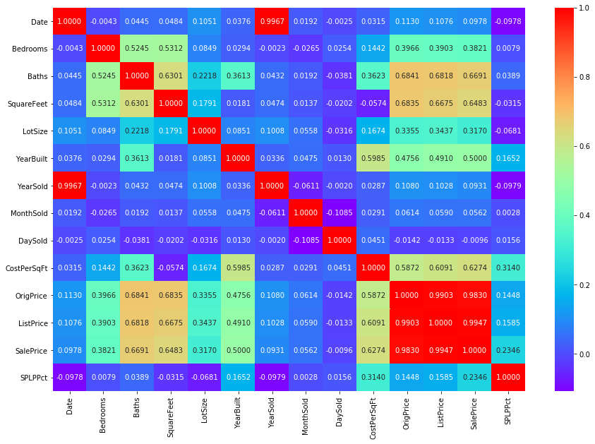

```python
plt.figure(figsize=(15,10))
sns.heatmap(df.corr(),annot=True,fmt='.4f',cmap='rainbow')
plt.show()
```

- OrigPrice, ListPrice and SalePrice have highest correlation,
- Date and YearSold also have very high correlation ~0.99.This will cause high multicollinearity

**Plot a boxplot for checking Outliers**

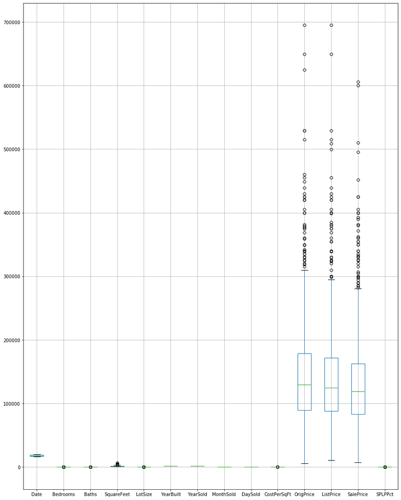

```python
fig = plt.figure(figsize = (15,20))
ax = fig.gca()
df.boxplot()
plt.show()
```

**Outlier Removal Using IQR method**

```python
Q1 = df.quantile(0.25)
Q3 = df.quantile(0.75)
IQR = Q3 - Q1
df_filtered=df[~((df < (Q1 - 1.5 * IQR)) |(df > (Q3 + 1.5 * IQR))).any(axis=1)]
```

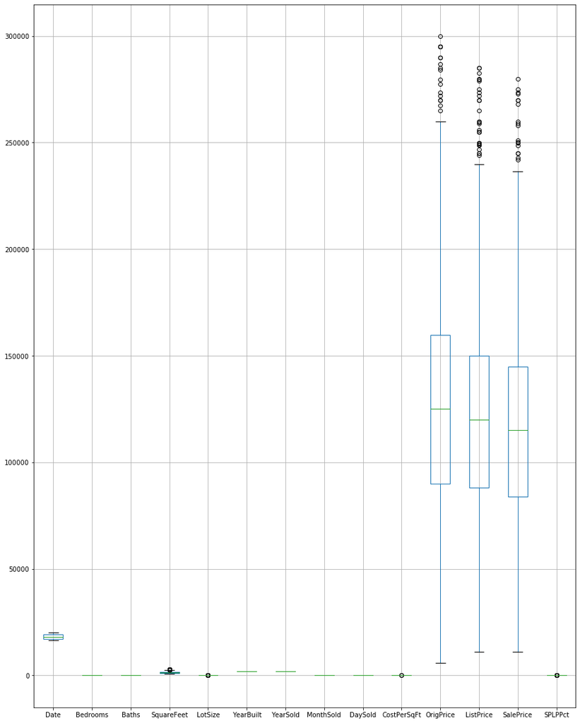

```python
fig = plt.figure(figsize = (15,20))
ax = fig.gca()
df_filtered.boxplot()
plt.show()
```

```python
df_filtered.shape #seems like it didnt work that good, can you see there are still some outliers
```

```
(726, 15)
```

**Make Histograms, DistPlots, Scatter Plots and give inferences about the data**

```python
cols=df.dtypes[df.dtypes!='object'].index #taking only numerical attributes
```

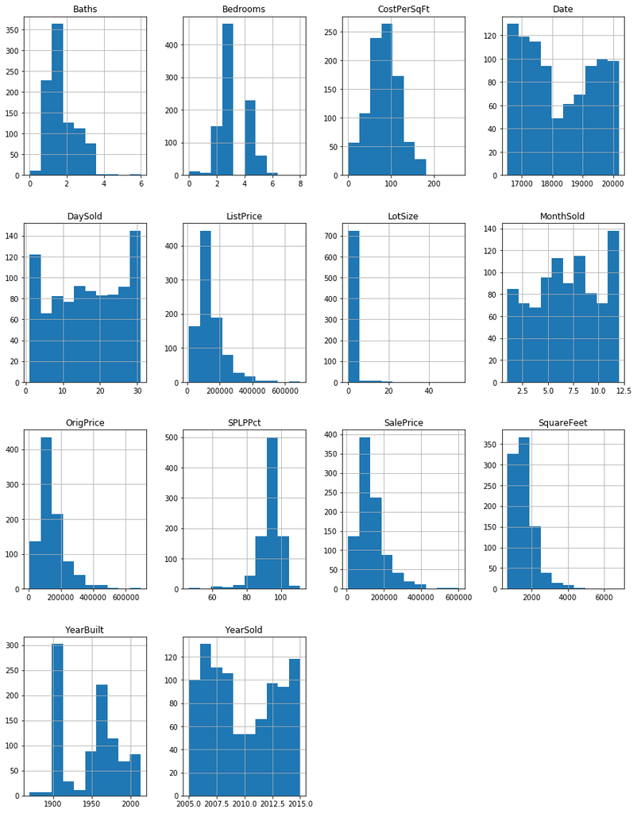

```python
fig = plt.figure(figsize = (15,20)) #figure size
ax = fig.gca() #this function adds as many as subplots as required depending upon number of columns
df[cols].hist(ax=ax) #histogram for numerical columns where axis ax is passed
plt.show()
```

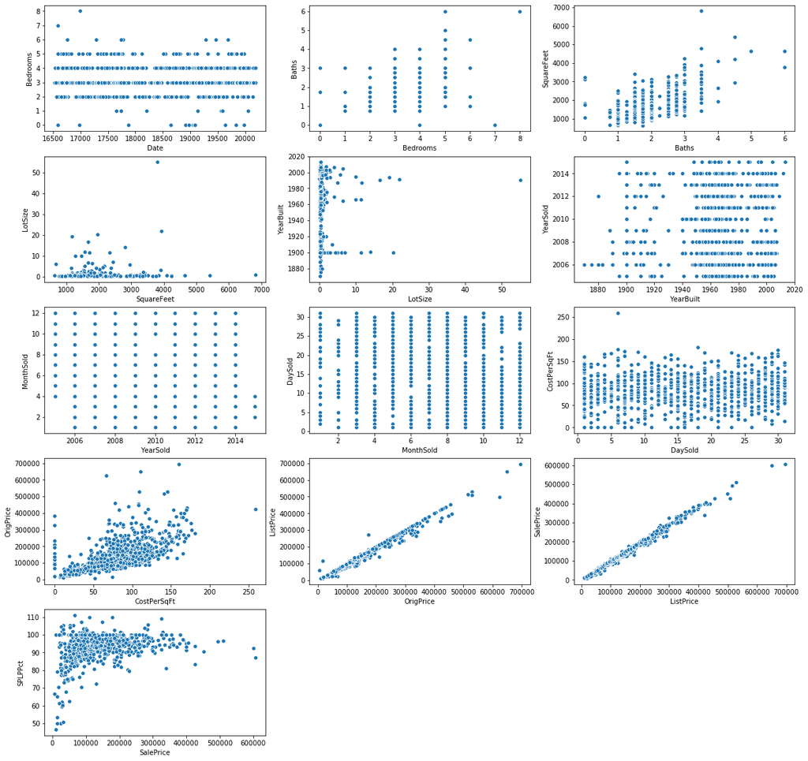

```python
df_no=df[cols] # only taking numerical attributes
fig = plt.figure(figsize=(20,20))
fig.subplots_adjust(hspace=0.2, wspace=0.2) #defining spacing between subplots height & width
for i in range(1,14): #range in number of attributes in the given dataset
    ax = fig.add_subplot(5, 3, i) #adding subplot
    sns.scatterplot(df_no[df_no.columns[i-1]],df_no[df_no.columns[i]]) #making scatterplot
plt.show()
```

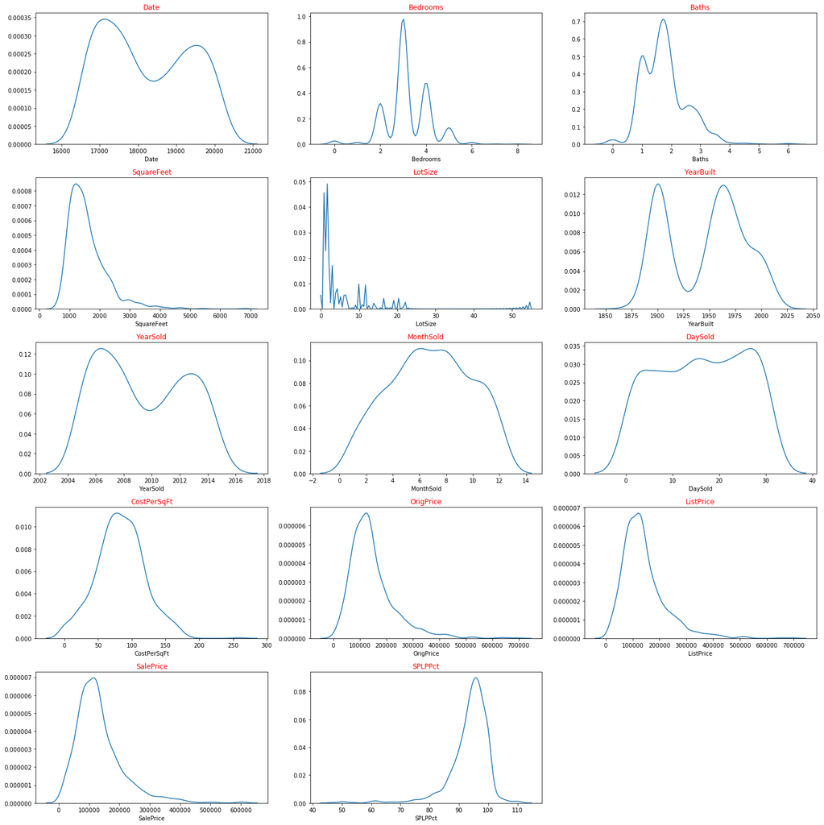

```python
cols=df.dtypes[df_filtered.dtypes!='object'].index
data_plot=df[cols]
fig=plt.figure(figsize=(20,20))
for i in range(0,len(data_plot.columns)):
    ax=fig.add_subplot(5,3,i+1)
    sns.distplot(data_plot[data_plot.columns[i]], hist=False)
    ax.set_title(data_plot.columns[i],color='Red')
plt.tight_layout()
plt.show()
```

**Check for Null Values**

```
The Total Null values are: 166
```

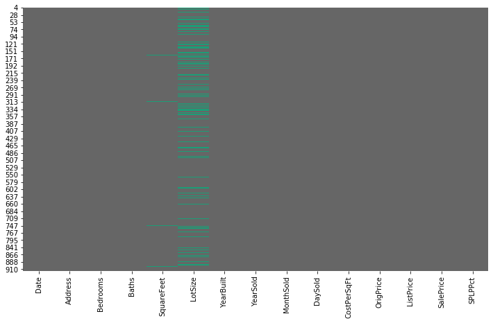

```
The Total Column wise Null values are:  Date             0
Address          0
Bedrooms         0
Baths            0
SquareFeet       9
LotSize        157
YearBuilt        0
YearSold         0
MonthSold        0
DaySold          0
CostPerSqFt      0
OrigPrice        0
ListPrice        0
SalePrice        0
SPLPPct          0
dtype: int64
```

```python
print('The Total Null values are:', df_filtered.isnull().sum().sum())
plt.figure(figsize=(12,7))
sns.heatmap(df_filtered.isnull(),cbar=False, cmap='Dark2_r')
plt.show()
print('The Total Column wise Null values are: ', df_filtered.isnull().sum())
```

##### In above plot, the green bars denote the Null Values and numbers on y-axis denotes the index values of data points which are Null

- LotSize seems to have highest number of Missing Values
- SquareFeet has only 9 missing values

**Split the Data**

```python
x=df_filtered.drop(['SalePrice','Address'],axis=1)
y=df_filtered['SalePrice']
x_train, x_test, y_train, y_test = train_test_split(x, y, test_size=0.20, random_state=123)
```

**Impute the Null Values**

```python
x_train.groupby(by='Bedrooms').mean()['LotSize']
#check average LotSize of houses depending upon its number of bedrooms
#though the mean lotsizes look similar bedrooms wise but let impute like this
```

```
Bedrooms
2    0.257306
3    0.284283
4    0.286732
5    0.267824
Name: LotSize, dtype: float64
```

```python
LotSize2=x_train[x_train.Bedrooms==2]['LotSize'].replace(np.NAN,x_train[x_train.Bedrooms==2]['LotSize'].mean())
LotSize3=x_train[x_train.Bedrooms==3]['LotSize'].replace(np.NAN,x_train[x_train.Bedrooms==3]['LotSize'].mean())
LotSize4=x_train[x_train.Bedrooms==4]['LotSize'].replace(np.NAN,x_train[x_train.Bedrooms==4]['LotSize'].mean())
LotSize5=x_train[x_train.Bedrooms==5]['LotSize'].replace(np.NAN,x_train[x_train.Bedrooms==5]['LotSize'].mean())
```

```python
imputed=pd.concat((LotSize2,LotSize3,LotSize4,LotSize5))
x_train=pd.merge(x_train,imputed,left_index=True,right_index=True).drop('LotSize_x',axis=1)
```

```python
x_train.isnull().sum()
```

```
Date           0
Bedrooms       0
Baths          0
SquareFeet     8
YearBuilt      0
YearSold       0
MonthSold      0
DaySold        0
CostPerSqFt    0
OrigPrice      0
ListPrice      0
SPLPPct        0
LotSize_y      0
dtype: int64
```

```python
#perform similar operation on test set
x_test.groupby(by='Bedrooms').mean()['LotSize']
LotSize2=x_test[x_test.Bedrooms==2]['LotSize'].replace(np.NAN,x_test[x_test.Bedrooms==2]['LotSize'].mean())
LotSize3=x_test[x_test.Bedrooms==3]['LotSize'].replace(np.NAN,x_test[x_test.Bedrooms==3]['LotSize'].mean())
LotSize4=x_test[x_test.Bedrooms==4]['LotSize'].replace(np.NAN,x_test[x_test.Bedrooms==4]['LotSize'].mean())
LotSize5=x_test[x_test.Bedrooms==5]['LotSize'].replace(np.NAN,x_test[x_test.Bedrooms==5]['LotSize'].mean())

imputed=pd.concat((LotSize2,LotSize3,LotSize4,LotSize5))
x_test=pd.merge(x_test,imputed,left_index=True,right_index=True).drop('LotSize_x',axis=1)

x_test.isnull().sum()
```

```
Date           0
Bedrooms       0
Baths          0
SquareFeet     1
YearBuilt      0
YearSold       0
MonthSold      0
DaySold        0
CostPerSqFt    0
OrigPrice      0
ListPrice      0
SPLPPct        0
LotSize_y      0
dtype: int64
```

```python
x_train.groupby(by='Bedrooms').mean()['SquareFeet']
```

```
Bedrooms
2    1081.929293
3    1371.568254
4    1766.750000
5    2028.266667
Name: SquareFeet, dtype: float64
```

```python
sq2=x_train[x_train.Bedrooms==2]['SquareFeet'].replace(np.NAN,x_train[x_train.Bedrooms==2]['SquareFeet'].mean())
sq3=x_train[x_train.Bedrooms==3]['SquareFeet'].replace(np.NAN,x_train[x_train.Bedrooms==3]['SquareFeet'].mean())
sq4=x_train[x_train.Bedrooms==4]['SquareFeet'].replace(np.NAN,x_train[x_train.Bedrooms==4]['SquareFeet'].mean())
sq5=x_train[x_train.Bedrooms==5]['SquareFeet'].replace(np.NAN,x_train[x_train.Bedrooms==5]['SquareFeet'].mean())
```

```python
imputed_sq=pd.concat((sq2,sq3,sq4,sq5))
x_train=pd.merge(x_train,imputed_sq,left_index=True,right_index=True).drop('SquareFeet_x',axis=1)
```

```python
x_train.shape
```

```
(580, 13)
```

```python
x_train.isnull().sum().sum()# no null values now. Well that was a very tedious approach, isn't it. What do you think?
# now you can use any approach you want to try, the dataset is small so this approach might not take much time
#but if dataset is huge, then what do you think can be an approach towards this.
#explore pyOD https://pyod.readthedocs.io/en/latest/
#lets move on
```

```
0
```

```python
sq2=x_test[x_test.Bedrooms==2]['SquareFeet'].replace(np.NAN,x_test[x_test.Bedrooms==2]['SquareFeet'].mean())
sq3=x_test[x_test.Bedrooms==3]['SquareFeet'].replace(np.NAN,x_test[x_test.Bedrooms==3]['SquareFeet'].mean())
sq4=x_test[x_test.Bedrooms==4]['SquareFeet'].replace(np.NAN,x_test[x_test.Bedrooms==4]['SquareFeet'].mean())
sq5=x_test[x_test.Bedrooms==5]['SquareFeet'].replace(np.NAN,x_test[x_test.Bedrooms==5]['SquareFeet'].mean())
imputed_sq=pd.concat((sq2,sq3,sq4,sq5))
x_test=pd.merge(x_test,imputed_sq,left_index=True,right_index=True).drop('SquareFeet_x',axis=1)

x_test.isnull().sum().sum()
```

```
0
```

**Linear Regression Model with and without Scaling**

```python
regression_model = LinearRegression()
regression_model.fit(x_train, y_train)
print("Linear Regression Train score without scaling:", regression_model.score(x_train, y_train))
print("Linear Regression Test score without scaling:", regression_model.score(x_test, y_test))
print("Linear Regression Train RMSE score without scaling:", np.sqrt(mean_squared_error(y_train,regression_model.predict(x_train))))
print("Linear Regression Test RMSE score without scaling:", np.sqrt(mean_squared_error(y_test,regression_model.predict(x_test))))

ss=StandardScaler()
x_train_scaled=ss.fit_transform(x_train)
x_test_scaled=ss.transform(x_test)
regression_model = LinearRegression()
regression_model.fit(x_train_scaled, y_train)
print('\n')
print("Linear Regression Train score with scaling:", regression_model.score(x_train_scaled, y_train))
print("Linear Regression Test score with scaling:", regression_model.score(x_test_scaled, y_test))
print("Linear Regression Train RMSE score with scaling:", np.sqrt(mean_squared_error(y_train,regression_model.predict(x_train_scaled))))
print("Linear Regression Test RMSE score with scaling:", np.sqrt(mean_squared_error(y_test,regression_model.predict(x_test_scaled))))
```

```
Linear Regression Train score without scaling: 0.9976331541364355
Linear Regression Test score without scaling: 0.9979701222174755
Linear Regression Train RMSE score without scaling: 2556.0121512931432
Linear Regression Test RMSE score without scaling: 1909.3725667116466


Linear Regression Train score with scaling: 0.997633154136433
Linear Regression Test score with scaling: 0.9979701222174702
Linear Regression Train RMSE score with scaling: 2556.0121512945047
Linear Regression Test RMSE score with scaling: 1909.372566714127
```

**No difference?**

### Bias-Variance Trade-Off in Multiple Regression

Both the bias and the variance are desired to be low, as large values of both can result in poor predictions from the model

- Bias : The model is not learning anything (under-fitting)
- Variance: The model is over-fitting and train score is very high (~1.0) while test score is very low.

The tradeoff is a point of moderate Bias and Variance to make a model with good prediction power

The Linear Regression can have a high variance because of the following:

- The predictors are highly correlated with each other;
- There are too many predictors

The general solution to this is to reduce variance by introducing some bias.This approach is called regularization

**LASSO Regression (Least Absolute Shrinkage and Selection Operator)**

L1 Regularization penalizes coefficients with the sum of their absolute values. For high values of λ, many coefficients can shrunk to 0

The cost function is defined as:

$L = \Sigma ( Y_i - \hat{Y_i} )^{2} + \lambda \Sigma |\beta_i| $

As $\lambda$ approaches 0, LASSO Regression Coefficients tends to become same as Linear Regression Coefficients

- Lasso can set some coefficients to zero, thus performing variable selection

```python
lasso = linear_model.Lasso(alpha=200)
lasso.fit(x_train, y_train)
print("LASSO Regression Train score without scaling:", lasso.score(x_train, y_train))
print("LASSO Regression Test score without scaling:", lasso.score(x_test, y_test))
print("LASSO Regression Train RMSE score without scaling:", np.sqrt(mean_squared_error(y_train,lasso.predict(x_train))))
print("LASSO Regression Test RMSE score without scaling:", np.sqrt(mean_squared_error(y_test,lasso.predict(x_test))))

lasso.fit(x_train_scaled, y_train)
print('\n')
print("LASSO Regression Train score with scaling:", lasso.score(x_train_scaled, y_train))
print("LASSO Regression Test score with scaling:", lasso.score(x_test_scaled, y_test))
print("LASSO Regression Train RMSE score with scaling:", np.sqrt(mean_squared_error(y_train,lasso.predict(x_train_scaled))))
print("LASSO Regression Test RMSE score with scaling:", np.sqrt(mean_squared_error(y_test,lasso.predict(x_test_scaled))))
```

```
LASSO Regression Train score without scaling: 0.9976216245878068
LASSO Regression Test score without scaling: 0.9979533182417631
LASSO Regression Train RMSE score without scaling: 2562.230102640869
LASSO Regression Test RMSE score without scaling: 1917.2594753175838


LASSO Regression Train score with scaling: 0.9975765026223951
LASSO Regression Test score with scaling: 0.9978487058767662
LASSO Regression Train RMSE score with scaling: 2586.4209123253086
LASSO Regression Test RMSE score with scaling: 1965.647456819253
```

**Ridge Regression**

L2 Regularization

The cost function is used to minimize the SSE but also penalize the coefficients so as to shrink them towards 0:

$L =\Sigma( Y_i - \hat{Y_i} )^{2} + \lambda \Sigma \beta_i^{2}$

As $\lambda$ approaches 0, Ridge Regression Coefficients tends to become same as Linear Regression Coefficients

- Scaling is necessary for ridge regression for giving equal penalty to coefficients and it also lowers $\lambda$ values

```python
ridge = linear_model.Ridge(alpha=200)
ridge.fit(x_train, y_train)
print("Ridge Regression Train score without scaling:", ridge.score(x_train, y_train))
print("Ridge Regression Test score without scaling:", ridge.score(x_test, y_test))
print("Ridge Regression Train RMSE score without scaling:", np.sqrt(mean_squared_error(y_train,ridge.predict(x_train))))
print("Ridge Regression Test RMSE score without scaling:", np.sqrt(mean_squared_error(y_test,ridge.predict(x_test))))

ridge.fit(x_train_scaled, y_train)
print('\n')
print("Ridge Regression Train score with scaling:", ridge.score(x_train_scaled, y_train))
print("Ridge Regression Test score with scaling:", ridge.score(x_test_scaled, y_test))
print("Ridge Regression Train RMSE score with scaling:", np.sqrt(mean_squared_error(y_train,ridge.predict(x_train_scaled))))
print("Ridge Regression Test RMSE score with scaling:", np.sqrt(mean_squared_error(y_test,ridge.predict(x_test_scaled))))
```

```
Ridge Regression Train score without scaling: 0.9976226557846265
Ridge Regression Test score without scaling: 0.9979350593491687
Ridge Regression Train RMSE score without scaling: 2561.6745868939006
Ridge Regression Test RMSE score without scaling: 1925.7926301894474


Ridge Regression Train score with scaling: 0.9712236161521598
Ridge Regression Test score with scaling: 0.9679478044169105
Ridge Regression Train RMSE score with scaling: 8912.428011977134
Ridge Regression Test RMSE score with scaling: 7587.254038358185
```

**Elastic Net**

Linear regression SSE with combination of Ridge and LASSO:

$L = \Sigma ( Y_i - \hat{Y_i} )^{2} + \lambda_1 \Sigma |\beta_i| + \lambda_2 \Sigma \beta_i ^{2} $

```python
eln = linear_model.ElasticNet(alpha=100)
eln.fit(x_train, y_train)
print("Elastic Net Regression Train score without scaling:", eln.score(x_train, y_train))
print("Elastic Net Regression Test score without scaling:", eln.score(x_test, y_test))
print("Elastic Net Regression Train RMSE score without scaling:", np.sqrt(mean_squared_error(y_train,eln.predict(x_train))))
print("Elastic Net Regression Test RMSE score without scaling:", np.sqrt(mean_squared_error(y_test,eln.predict(x_test))))

eln.fit(x_train_scaled, y_train)
print('\n')
print("Elastic Net Regression Train score with scaling:", eln.score(x_train_scaled, y_train))
print("Elastic Net Regression Test score with scaling:", eln.score(x_test_scaled, y_test))
print("Elastic Net Regression Train RMSE score with scaling:", np.sqrt(mean_squared_error(y_train,eln.predict(x_train_scaled))))
print("Elastic Net Regression Test RMSE score with scaling:", np.sqrt(mean_squared_error(y_test,eln.predict(x_test_scaled))))
```

```
Elastic Net Regression Train score without scaling: 0.993495774245378
Elastic Net Regression Test score without scaling: 0.9909306681114878
Elastic Net Regression Train RMSE score without scaling: 4237.1684453356465
Elastic Net Regression Test RMSE score without scaling: 4035.9277302782025


Elastic Net Regression Train score with scaling: 0.12791927883026888
Elastic Net Regression Test score with scaling: 0.11582938264625087
Elastic Net Regression Train RMSE score with scaling: 49063.245025566575
Elastic Net Regression Test RMSE score with scaling: 39849.58221447041
```

**Inferences from LASSO, Ridge and Elastic Net**

- Which model becomes more biased even for a small alpha when scaled?

Elastic Net has very low R Squared value at alpha =100

- Does scaling impact the results in Ridge, LASSO and Elastic Net?

Scaling does seem to impact Elastic Net and Ridge Regression models. With high Alpha values, the RMSE is increased.

- How many variables have been shrunk to zero by LASSO?

```python
lasso.coef_
```

```
array([    0.        ,     0.        ,     0.        ,     0.        ,
           0.        ,     0.        ,     0.        ,   280.98195023,
           0.        , 51564.34092306,  4599.60051835,     0.        ,
           0.        ])
```

### Now that you have finished this much, try to change alpha values, do feature engineering, etc. Try other algorithms to this dataset like Random Forest Regressor

```
                                                Happy Learning!
```